# Analysis of all RADAR validation studies

Inka Marie Spyridonov

2024-12-17

## Reproducible environment

In case you want to make sure that you are creating the exact same output as presented in the publication, you need to create the reproducible environment using `rix` and `nix`. Using `rix`, you can run the following function to create your nix script. The nix script is however already in the vignettes folder within `xeredar` available as default.nix file.

```r
rix::rix(
  r_ver = "latest",
  r_pkgs = c("tidyverse", "tidyr", "purrr", "furrr", "gt","easystats","rlang", "DHARMa", "devtools", "patchwork", "rmarkdown"),
  system_pkgs = NULL,
  tex_pkgs = c("amsmath"),
  git_pkgs = list(package_name = "xeredar",
                  repo_url = "https://github.com/basf/xeredar",
                  commit = "2b85763"),
  ide = "rstudio",
  project_path = "./vignettes",
  overwrite = TRUE
)
```

Once the default.nix file was created in the path you specified in the command above (`project_path`) you need to type `nix-build` into the terminal. Once the shell was built you can open it via `nix-shell`. You can open Rstudio by first running this line in the terminal: `export QT_XCB_GL_INTEGRATION=none` and then running `rstudio`. Rstudio will open and you will have access to all files located at the path you specified in the `rix` function. You can run the script as usual. Through this approach, the code and results are reproducible.

The following sections contain the code that needs to be executed to reproduce the analysis.

### Functions

```r
decreasing_alpha <- function(df, vector){
  for(i in vector){
    result <- xeredar::data_prep(df, row=FALSE, alpha = i, trim=FALSE, outlier = FALSE)
    if(is.list(result)){
      break
    } else{
      next
    }
  }
  result[["alpha"]] <- i
  return(result)
}



changing_alpha <- sort(c(c(1,5) %o% 10^-(2:17), 0), decreasing = TRUE)[-1]


check <- function(list_dfs, id){
  result <- tryCatch({
    decreasing_alpha(list_dfs, changing_alpha)
    }, error = function(e) {
      list(error = paste("Error xeredar provides an error"))
      })
  setNames(list(result), id)
}



check_positive <- function(df){
  if(length(df) ==1){
    return(NA)}

  if(df[["Monotonicity Test"]]$`Pr(>|t|)`[1] >= 0.01 &
     df[["Monotonicity Test"]]$`Pr(>|t|)`[2] <= 0.01 ) {
    return(df[["Dunnetts"]])
  } else if (length(unique(df$WilliamsIncrease$Y.Tilde)) - 1 > floor(nrow(df$WilliamsIncrease)/2) |
             length(unique(df$WilliamsDecrease$Y.Tilde)) - 1 > floor(nrow(df$WilliamsDecrease)/2)) {
    return(list(WilliamsIncrease = df[["WilliamsIncrease"]], WilliamsDecrease = df[["WilliamsDecrease"]]))
  } else{
    return(df[["Dunnetts"]])
  }
}



significances <- function(df, Williams= FALSE){
  if(!is.list(df)){
    return(NA)}
  if(Williams) {
    if(TRUE %in% df[["WilliamsIncrease"]]$Sign){
        return("sign_Incr")
      }
    if(TRUE %in% df[["WilliamsDecrease"]]$Sign){
        return("sign_Decr")
      }
    else{
      return("Nonsignificant")
    }
    }
  else{
    if(df[["adj p"]][length(df[["adj p"]])] < 0.05){
      if(df[["Estimate"]][length(df[["Estimate"]])] > 0){
        return("sign_Incr")
      } else{
        return("sign_Decr")
      }
    } else{
      return("Nonsignificant")
  }
  }
}
```

### Checking all RADAR validation studies for ED activity

```r
devtools::install_github("thomasp85/patchwork")
#devtools::install_github("basf/xeredar")
purrr::map(c("tidyverse","tidyr", "purrr", "furrr", "gt","easystats","rlang","drc", "DHARMa", "devtools", "patchwork"), require, character.only = TRUE)
library(patchwork)
```

```r
anovas <- purrr::imap(xeredar::RADAR_valid_data_table_spiked_unspiked, ~ check(.x, .y)) |> purrr::flatten()
```

```r
anovas_unspiked <- anovas[stringr::str_detect(names(anovas), "Unspiked")]
anovas_spiked<- anovas[!stringr::str_detect(names(anovas), "Unspiked")]

results_Spiked <- purrr::map(anovas_spiked, check_positive)
results_Unspiked <- purrr::map(anovas_unspiked, check_positive)

Williams_Spiked <- !purrr::map_vec(results_Spiked, is.data.frame)
Williams_Unspiked <- !purrr::map_vec(results_Unspiked, is.data.frame)

significances_Spiked <- purrr::map2(results_Spiked, Williams_Spiked, significances) |>
  dplyr::bind_rows(.id = "CompoundLab") |>
  tidyr::pivot_longer(
    cols = 1:44,
    names_to = "CompoundLab",
    values_to = "Spiked_sign"
  ) |>
    dplyr::mutate(CompoundLab = stringr::str_remove(CompoundLab,"_Spiked"))


significances_Unspiked <- purrr::map2(results_Unspiked, Williams_Unspiked, significances) |>
  dplyr::bind_rows(.id = "CompoundLab") |>
  tidyr::pivot_longer(
    cols = 1:44,
    names_to = "CompoundLab",
    values_to = "Unspiked_sign"
  ) |>
    dplyr::mutate(CompoundLab = stringr::str_remove(CompoundLab,"_Unspiked"))



desired_order <- c(
  "AmantadineWATCHFR", "AmantadineCEFAS", "AmantadineFIWI", "AmantadineFRAUNH", "AmantidineIDEA",
  "LDopaWATCHFR", "ArabinoseWATCHFR", "CefuroximeWATCHFR", "CefuroximeCEFAS", "CefuroximeFIWI",
  "CefuroximeFRAUNH", "CefuroximeIDEA", "CromolynWATCHFR", "CromolynCEFAS", "CromolynFIWI",
  "CromolynIDEA", "AnastrazoleWATCHFR", "AnastrozoleCEFAS", "AnastrozoleFIWI", "AnastrozoleIDEA",
  "ProchlorazWATCHFR", "DutasterideWATCHFR", "CyproteroneWATCHFR", "FenitrothionWATCHFR",
  "FenitrothionCEFAS", "FenitrothionFIWI", "FenitrothionIDEA", "EstradiolWATCHFR", "mDHTWATCHFR",
  "mDHTCEFAS", "mDHTFIWI", "mDHTFRAUNH", "mDHTIDEA", "TrenboloneWATCHFR", "LinuronWATCHFR",
  "LinuronCEFAS", "LinuronFIWI", "LinuronFRAUNH", "LinuronIDEA", "VinclozolinWATCHFR",
  "VinclozolinCEFAS", "VinclozolinFIWI", "VinclozolinFRAUNH", "vinclozolinIDEA"
)

Result_Radar_valid <- dplyr::full_join(significances_Spiked, significances_Unspiked) |>
    dplyr::mutate(`Known Mode of Action` =
        dplyr::case_when(
            stringr::str_detect(CompoundLab, "Amantadine|Amantidine|LDopa|Arabinose|Cefuroxime|Cromolyn") ~ "no EAS MoA",
            stringr::str_detect(CompoundLab, "Anastrozole|Anastrazole") ~ "steroidogenesis (anti-E): aromatase inhibitor (competitive)",
            stringr::str_detect(CompoundLab, "Prochloraz") ~ "steroidogenesis (anti-E): aromatase inhibitor (transcriptional)",
            stringr::str_detect(CompoundLab, "Dutasteride") ~ "steroidogenesis: 5alpha reductase inhibitor; AR antagonist (high conc.)",
            stringr::str_detect(CompoundLab, "Cyproterone|Fenitrothion") ~ "anti-A: AR antagonist",
            stringr::str_detect(CompoundLab, "Estradiol") ~ "E: ER agonist; steroidogenesis (anti-A): aromatase inducer",
            stringr::str_detect(CompoundLab, "mDHT|Trenbolone") ~ "A: non-aromatizable AR agonist",
            stringr::str_detect(CompoundLab, "Linuron") ~ "anti-A: AR antagonist; anti-E",
            stringr::str_detect(CompoundLab, "Vinclozolin|vinclozolin") ~ "anti-A: AR antagonist; E: weak ER agonist"
        ),
        CompoundLab = factor(CompoundLab, levels = desired_order)
    ) |>
    dplyr::arrange(CompoundLab) |>
    dplyr::mutate(`Final Conclusion` = c(
        'A(S)-inactive', 'A(S)-inactive', 'A(S)-inactive', 'A(S)-inactive', 'A(S)-inactive', 'A(S)-inactive', 'active', 'A(S)-inactive', 'A(S)-inactive', 'A(S)-inactive', 'A(S)-inactive', 'A(S)-inactive', 'A(S)-inactive', 'A(S)-inactive', 'A(S)-inactive', 'A(S)-inactive', 'S-active', 'S-active', 'S-active', 'inactive', 'inactive', 'A-active', 'A-active', 'A-active', 'A-active', 'A-active', 'A-active','S-active', 'A-active', 'A-active', 'A-active', 'A-active', 'A-active', 'A-active', 'A-active', 'A-active', 'inactive', 'A-active', 'A-active', 'A-active','A-active','A-active',' A-active', 'A-active'
    ))  |>
    dplyr::mutate(Compound= stringr::str_remove(CompoundLab, "WATCHFR|CEFAS|FIWI|FRAUNH|IDEA"),
                  Lab = stringr::str_extract(CompoundLab, "WATCHFR|CEFAS|FIWI|FRAUNH|IDEA")) |>
    dplyr::select(-CompoundLab) |>
    dplyr::relocate(c("Compound", "Lab", "Known Mode of Action", "Spiked_sign", "Unspiked_sign", "Final Conclusion")) |>
    dplyr::mutate(Compound = dplyr::if_else(Compound == "vinclozolin", "Vinclozolin", Compound))
```

```r
gt::gt(Result_Radar_valid) |>
    gt::tab_style(
    style = list(
      gt::cell_fill(color = "green")
    ),
    locations = gt::cells_body(
      columns = c(`Final Conclusion`), # not needed if coloring all columns
      rows = c(1:6, 8:19, 22:36, 38:42, 43:44))) |>
    gt::tab_style(
      style = list(
      gt::cell_fill(color = "red")
      ),
      locations = gt::cells_body(
        columns = (`Final Conclusion`),
        rows = 7
      )
    ) |>
    gt::tab_style(
      style = list(
      gt::cell_fill(color = "blue")
      ),
      locations = gt::cells_body(
        columns = (`Final Conclusion`),
        rows = c(20:21, 37)
      )
    ) |>
  gt::tab_style(
      style = list(
      gt::cell_fill(color = "orange")
      ),
      locations = gt::cells_body(
        columns = (Unspiked_sign),
        rows = c(9, 18, 25)
      )
    ) |>
  gt::tab_style(
      style = list(
      gt::cell_fill(color = "purple")
      ),
      locations = gt::cells_body(
        columns = (Unspiked_sign),
        rows = c(7,27,35)
      )
    ) |>
  gt::tab_style(
      style = list(
      gt::cell_fill(color = "purple")
      ),
      locations = gt::cells_body(
        columns = (Spiked_sign),
        rows = c(20:21, 34, 37)
      )
    )
```

| Compound | Lab | Known Mode of Action | Spiked_sign | Unspiked_sign | Final Conclusion |
| --- | --- | --- | --- | --- | --- |
| Amantadine | WATCHFR | no EAS MoA | Nonsignificant | Nonsignificant | A(S)-inactive |
| Amantadine | CEFAS | no EAS MoA | Nonsignificant | Nonsignificant | A(S)-inactive |
| Amantadine | FIWI | no EAS MoA | Nonsignificant | Nonsignificant | A(S)-inactive |
| Amantadine | FRAUNH | no EAS MoA | Nonsignificant | Nonsignificant | A(S)-inactive |
| Amantidine | IDEA | no EAS MoA | Nonsignificant | Nonsignificant | A(S)-inactive |
| LDopa | WATCHFR | no EAS MoA | Nonsignificant | Nonsignificant | A(S)-inactive |
| Arabinose | WATCHFR | no EAS MoA | Nonsignificant | sign_Incr | active |
| Cefuroxime | WATCHFR | no EAS MoA | Nonsignificant | Nonsignificant | A(S)-inactive |
| Cefuroxime | CEFAS | no EAS MoA | Nonsignificant | sign_Decr | A(S)-inactive |
| Cefuroxime | FIWI | no EAS MoA | Nonsignificant | Nonsignificant | A(S)-inactive |
| Cefuroxime | FRAUNH | no EAS MoA | Nonsignificant | Nonsignificant | A(S)-inactive |
| Cefuroxime | IDEA | no EAS MoA | Nonsignificant | NA | A(S)-inactive |
| Cromolyn | WATCHFR | no EAS MoA | Nonsignificant | Nonsignificant | A(S)-inactive |
| Cromolyn | CEFAS | no EAS MoA | Nonsignificant | Nonsignificant | A(S)-inactive |
| Cromolyn | FIWI | no EAS MoA | Nonsignificant | Nonsignificant | A(S)-inactive |
| Cromolyn | IDEA | no EAS MoA | Nonsignificant | NA | A(S)-inactive |
| Anastrazole | WATCHFR | steroidogenesis (anti-E): aromatase inhibitor (competitive) | sign_Incr | Nonsignificant | S-active |
| Anastrozole | CEFAS | steroidogenesis (anti-E): aromatase inhibitor (competitive) | sign_Incr | sign_Decr | S-active |
| Anastrozole | FIWI | steroidogenesis (anti-E): aromatase inhibitor (competitive) | sign_Incr | Nonsignificant | S-active |
| Anastrozole | IDEA | steroidogenesis (anti-E): aromatase inhibitor (competitive) | Nonsignificant | Nonsignificant | inactive |
| Prochloraz | WATCHFR | steroidogenesis (anti-E): aromatase inhibitor (transcriptional) | Nonsignificant | Nonsignificant | inactive |
| Dutasteride | WATCHFR | steroidogenesis: 5alpha reductase inhibitor; AR antagonist (high conc.) | Nonsignificant | sign_Incr | A-active |
| Cyproterone | WATCHFR | anti-A: AR antagonist | sign_Decr | Nonsignificant | A-active |
| Fenitrothion | WATCHFR | anti-A: AR antagonist | sign_Decr | Nonsignificant | A-active |
| Fenitrothion | CEFAS | anti-A: AR antagonist | sign_Decr | sign_Decr | A-active |
| Fenitrothion | FIWI | anti-A: AR antagonist | sign_Decr | Nonsignificant | A-active |
| Fenitrothion | IDEA | anti-A: AR antagonist | sign_Decr | sign_Incr | A-active |
| Estradiol | WATCHFR | E: ER agonist; steroidogenesis (anti-A): aromatase inducer | sign_Decr | Nonsignificant | S-active |
| mDHT | WATCHFR | A: non-aromatizable AR agonist | Nonsignificant | sign_Incr | A-active |
| mDHT | CEFAS | A: non-aromatizable AR agonist | Nonsignificant | sign_Incr | A-active |
| mDHT | FIWI | A: non-aromatizable AR agonist | Nonsignificant | sign_Incr | A-active |
| mDHT | FRAUNH | A: non-aromatizable AR agonist | Nonsignificant | sign_Incr | A-active |
| mDHT | IDEA | A: non-aromatizable AR agonist | Nonsignificant | sign_Incr | A-active |
| Trenbolone | WATCHFR | A: non-aromatizable AR agonist | sign_Incr | sign_Incr | A-active |
| Linuron | WATCHFR | anti-A: AR antagonist; anti-E | sign_Decr | sign_Incr | A-active |
| Linuron | CEFAS | anti-A: AR antagonist; anti-E | sign_Decr | Nonsignificant | A-active |
| Linuron | FIWI | anti-A: AR antagonist; anti-E | Nonsignificant | Nonsignificant | inactive |
| Linuron | FRAUNH | anti-A: AR antagonist; anti-E | sign_Decr | Nonsignificant | A-active |
| Linuron | IDEA | anti-A: AR antagonist; anti-E | sign_Decr | Nonsignificant | A-active |
| Vinclozolin | WATCHFR | anti-A: AR antagonist; E: weak ER agonist | sign_Decr | Nonsignificant | A-active |
| Vinclozolin | CEFAS | anti-A: AR antagonist; E: weak ER agonist | sign_Decr | Nonsignificant | A-active |
| Vinclozolin | FIWI | anti-A: AR antagonist; E: weak ER agonist | sign_Decr | Nonsignificant | A-active |
| Vinclozolin | FRAUNH | anti-A: AR antagonist; E: weak ER agonist | sign_Decr | Nonsignificant | A-active |
| Vinclozolin | IDEA | anti-A: AR antagonist; E: weak ER agonist | sign_Decr | Nonsignificant | A-active |

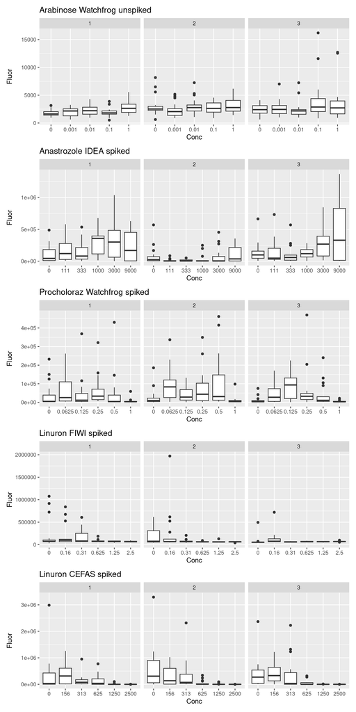

```r
arabinoseWATCHFR_unspiked <- xeredar::RADAR_valid_data_table_spiked_unspiked[["ArabinoseWATCHFR_Unspiked"]] |>
  ggplot2::ggplot(ggplot2::aes(x= Conc, y = Fluor)) +
  ggplot2::geom_boxplot() +
  ggplot2::facet_wrap(ggplot2::vars(Replicate)) +
  ggplot2::ggtitle("Arabinose Watchfrog unspiked")

anastrozoleIDEA_spiked <- xeredar::RADAR_valid_data_table_spiked_unspiked[["AnastrozoleIDEA_Spiked"]] |>
   ggplot2::ggplot(ggplot2::aes(x= Conc, y = Fluor)) +
    ggplot2::geom_boxplot() +
    ggplot2::facet_wrap(ggplot2::vars(Replicate)) +
    ggplot2::ggtitle("Anastrozole IDEA spiked")

prochlorazWATCHFR_spiked <- xeredar::RADAR_valid_data_table_spiked_unspiked[["ProchlorazWATCHFR_Spiked"]] |>
   ggplot2::ggplot(ggplot2::aes(x= Conc, y = Fluor)) +
    ggplot2::geom_boxplot() +
    ggplot2::facet_wrap(ggplot2::vars(Replicate)) +
    ggplot2::ggtitle("Procholoraz Watchfrog spiked")

fenitrothionIDEA_spiked <- xeredar::RADAR_valid_data_table_spiked_unspiked[["LinuronFIWI_Spiked"]] |>
  ggplot2::ggplot(ggplot2::aes(x= Conc, y = Fluor)) +
    ggplot2::geom_boxplot() +
    ggplot2::facet_wrap(ggplot2::vars(Replicate)) +
    ggplot2::ggtitle("Linuron FIWI spiked")

fenitrothionCEFAS_spiked <- xeredar::RADAR_valid_data_table_spiked_unspiked[["LinuronCEFAS_Spiked"]] |>
  ggplot2::ggplot(ggplot2::aes(x= Conc, y = Fluor)) +
    ggplot2::geom_boxplot() +
    ggplot2::facet_wrap(ggplot2::vars(Replicate)) +
    ggplot2::ggtitle("Linuron CEFAS spiked")

arabinoseWATCHFR_unspiked/
anastrozoleIDEA_spiked/
prochlorazWATCHFR_spiked/
fenitrothionIDEA_spiked/
fenitrothionCEFAS_spiked
```